# MSDS 7333 Fall 2020: Case Study 1

Jayson Barker, Brandon Croom, Shane Winestock

# Business Understanding

Organizations measure productivity in various ways depending upon the metrics they want to track. They may look at shipping times for materials, optimization of workflows within the organization, and any are focused on cost minimization. One such way organizations can help within this optimization is through leveraging real-time location systems (RTLS). Real-time location systems allow organizations to monitory assess and workers through the workflows that exist within the organization.

The evaluation of RTLS as is relates to an organizations WiFi usage is one such method to analyze productivity. More specifically, the distribution of various wifi-enabled RTLS devices across a facility may allow clustering methods to be leveraged in order to predict the position of assets based on previous patterns. In this particular evaluation data were provided for offline and online data across 6 access points. The building layout, access point configuration, online measurements (black dots), and offline measurements (gray dots) are shown below in Figure 1.

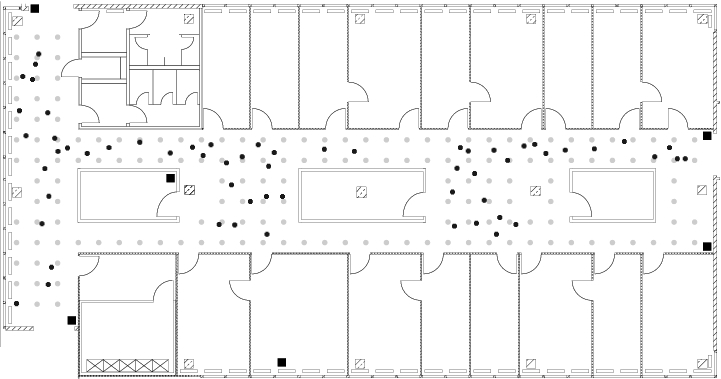

Figure 1: Building Floorplan

The objectives for this case study are:

- evaluate the data to determine the optimal access point configuration to include in the data
- evaluate both a regular unweighted KNN and weighted KNN methodology to perform predictions

# Data Engineering

In evaluating the data that has been made available it is critical to understand the data file structure. There are two data files to work with: Online.txt and Offline.txt. The Offline.txt file contains information relating to the offline measurements that were taken. The Online.txt file contains information relating to the online measurements that were taken. The Offline.txt file makes up the training data set while the Online.txt file is the test data set. Both files are structured with the data fields noted below:

| Data Field | Data Description |
| --- | --- |
| t | Time stamp in milliseconds |
| Id | Router MAC Address |
| Pos | Router Location (Comma separated positions for x, y, z) |
| Degree | Direction scanning device measured in degrees that was carried by the researcher |
| MAC | MAC address of either the router, or scanning device combined with corresponding values for signal strength (dBm), the mode in which it was operating(adhoc scanner = 1, access router = 3), and its cor… |
| Signal | Received Signal Strength in DbM |

As noted above, the data fields have compressed information into single columns. For example, the Pos column contains information for X,Y, and Z coordinates in comma delimited format instead of being broken out into individual fields. The same is true for the MAC column. The MAC column contains information on the router MAC address, signal strength, operating mode and channel. In order to handle all of this information data frames were constructed for both the online and offline data sets. Each field was split out into a column within the data frame in order to make analysis much easier.

In reviewing the data in raw form a few observations were identified:

- The Z position (i.e. elevation) was zero for the data points. This indicates a column that can be dropped for the specific analysis.
- The scan angles are not consistent and need to be made consistent. Plan to round these to the nearest 45 degree angle,
- There are some MAC addresses with only a few data points. A threshold of approximately 1 million will be set. Any MAC addresses with less than this threshold will be removed

In specific relation to this analysis the following features will also be dropped from the dataframe as they do not impact the analysis:

- scanMac - this is the MAC address of the scanner
- channel - this is the channel the data was read on
- type - this is the device type

Multiple columns will be created to assist in further analysis

- medSignal - this will be the median signal strength captured
- avgSignal - this will be the average signal strength captured
- sdSignal - this will be the standard deviation of the captured signal strength
- iqrSignal - this is the interquartile range of the captured signal strength
- posXY - this is a combintion of the posX, posY fields into a single value. Coordinates are separated by the ‘-’ character
- rawTime - this is a raw time value

For purposes of these analysis these rules were applied to both the online and offline data sets.

As part of the analysis the determination of certain access points to keep or remove was needed. Specifically evaluation of whether to individually keep both access points that ended in C0 and CD or to keep only one of these points. This need resulted in three distinct dataframes for each file as follows:

| Data Frame | Description |
| --- | --- |
| offlineSummary | The offline dataframe containing only the C0 access point |
| offlineSummary2 | The offline dataframe containing only the CD access point |
| offlineSummaryall | The offline dataframe containing both C0 and CD |
| onlineSummary | The online dataframe containing only the C0 access point |
| onlineSummary2 | The online dataframe containing only the CD access point |
| offlineSummaryall | The online dataframe containing both C0 and CD |

All of the dataframes have the same structure. For illustrative purposes a view of the offlineSummaryall dataframe showing the available features is below:

```r
summary.default(offlineSummaryall)
```

```
##             Length Class  Mode
## time        7968   POSIXt numeric
## posX        7968   -none- numeric
## posY        7968   -none- numeric
## orientation 7968   -none- numeric
## mac         7968   -none- character
## signal      7968   -none- numeric
## rawTime     7968   -none- numeric
## angle       7968   -none- numeric
## posXY       7968   -none- character
## medSignal   7968   -none- numeric
## avgSignal   7968   -none- numeric
## num         7968   -none- numeric
## sdSignal    7968   -none- numeric
## iqrSignal   7968   -none- numeric
```

In preparation for data modeling, the data has also been flattened to create a dataframe with a single positional entry (X, Y coordinate) for each MAC address. This will help to reduce the analysis record count down to approximately 1328 points per MAC address. this breakdown is shown below:

```
##                       time posX posY orientation               mac signal
## 7      2006-02-11 02:31:58    0    0         0.0 00:0f:a3:39:dd:cd    -75
## 24512  2006-02-11 03:03:44    0    1         0.7 00:0f:a3:39:dd:cd    -73
## 221777 2006-02-11 06:46:02    0   10         0.9 00:0f:a3:39:dd:cd    -69
## 229191 2006-02-11 06:54:05    0   11         0.4 00:0f:a3:39:dd:cd    -72
## 236493 2006-02-11 07:02:32    0   12         0.2 00:0f:a3:39:dd:cd    -72
## 243546 2006-02-11 07:14:12    0   13         0.1 00:0f:a3:39:dd:cd    -69
##             rawTime angle posXY medSignal avgSignal num sdSignal iqrSignal
## 7      1.139643e+12     0   0-0       -67 -68.12613 111 3.159739       4.5
## 24512  1.139645e+12     0   0-1       -70 -70.33636 110 2.420392       3.0
## 221777 1.139658e+12     0  0-10       -67 -69.24324 111 4.407053       6.5
## 229191 1.139659e+12     0  0-11       -73 -74.30631 111 5.396620       7.0
## 236493 1.139659e+12     0  0-12       -70 -69.57895 114 2.372015       3.0
## 243546 1.139660e+12     0  0-13       -74 -73.58716 109 3.493939       4.0
```

```
##                 mac count
## 1 00:0f:a3:39:dd:cd  1328
## 2 00:0f:a3:39:e1:c0  1328
## 3 00:14:bf:3b:c7:c6  1328
## 4 00:14:bf:b1:97:8a  1328
## 5 00:14:bf:b1:97:8d  1328
## 6 00:14:bf:b1:97:90  1328
```

Building the dataframes as described above with flattened data and dataframes containing the different access points allows for providing quick analysis of the data.

# Access Point Analysis

One of the analysis points that must be determined is whether to use the MAC address ending with C0 only, the MAC address ending in CD only, or to keep both in our data set. In order to determine which approach to take, the KNN methodolody will be executed on all three configurations. Using this information it can be determined which configuration will be used. The elbow plots shown below will assist in this determination

```
## [1] 659.4003
```

```
## [1] 306.7025
```

```
## [1] 275.5083
```

```
## [1] 273.6803
```

```
## [1] 296.4563
```

```
## [1] 411.6403
```

```
## [1] 270.4581
```

```
## [1] 249.9243
```

```
## [1] 258.075
```

```
## [1] 250.2583
```

[figure not shown]

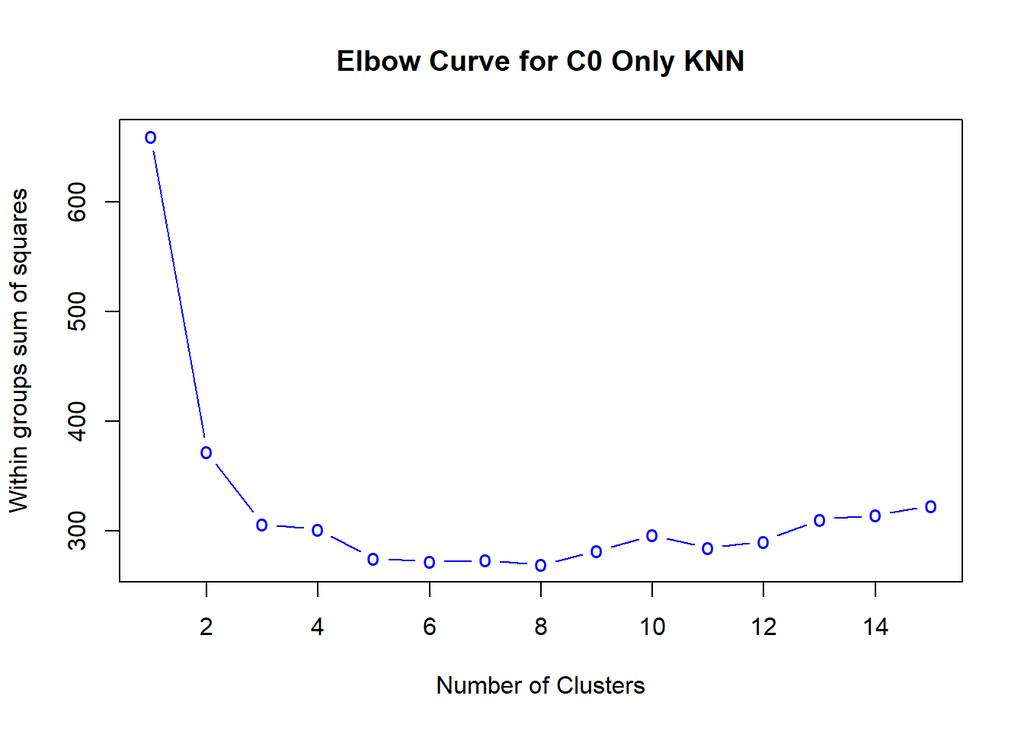

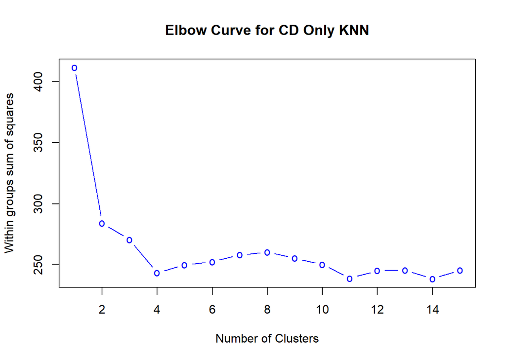

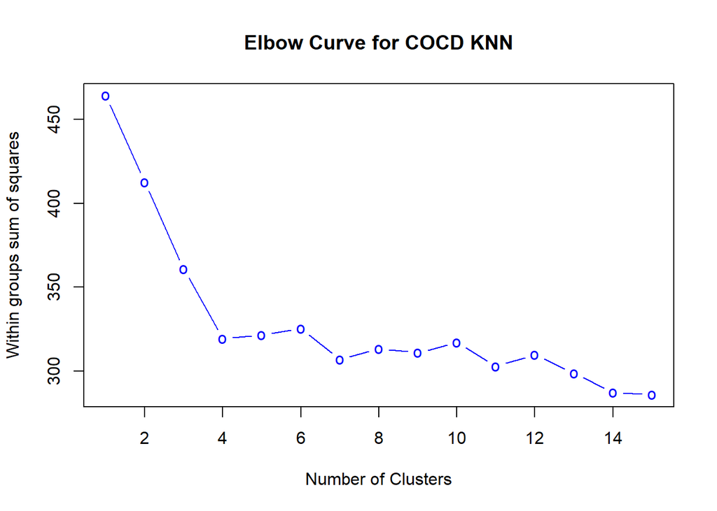

[output not shown]

```
## [1] "CD KNN Error at K=5: 249.924300"
```

```
## [1] "COCD KNN Error at K=7: 306.852137"
```